# Homework 2 - Multidimensional Scaling

Çağan Şengün - IE582 - Fall 2020

```r
library(readr)
library(dplyr)
```

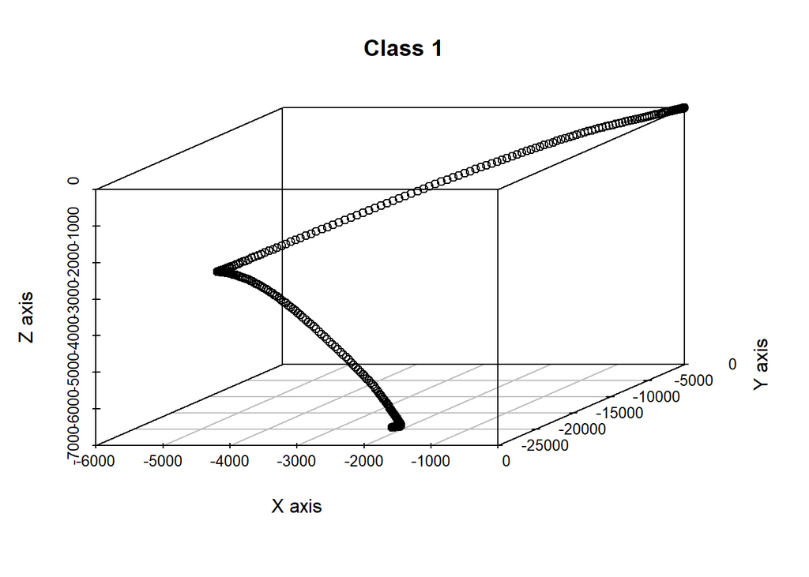

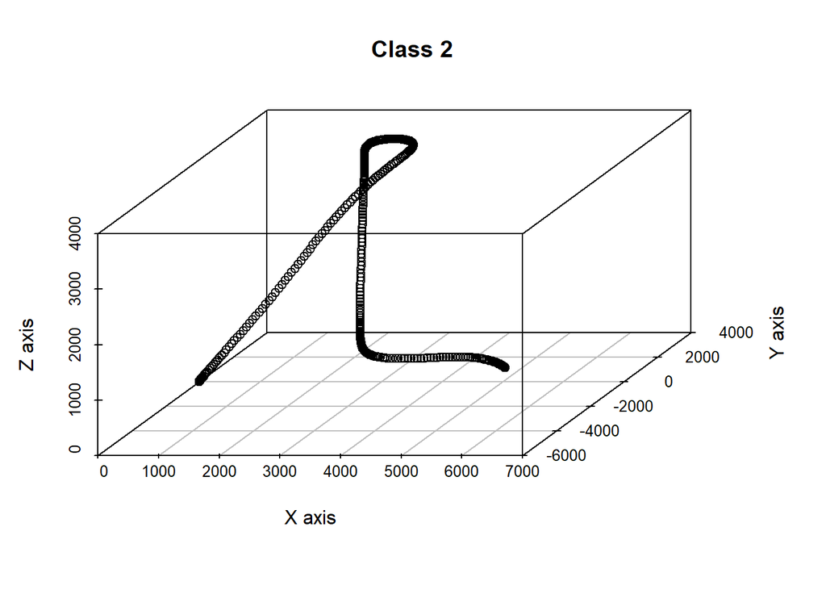

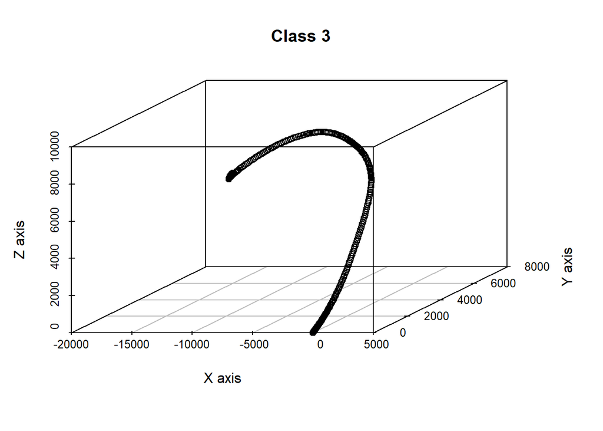

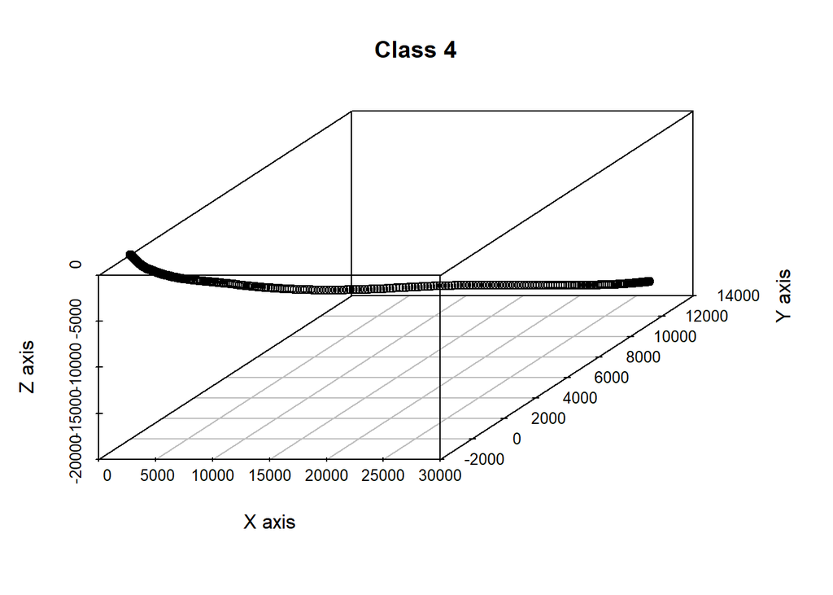

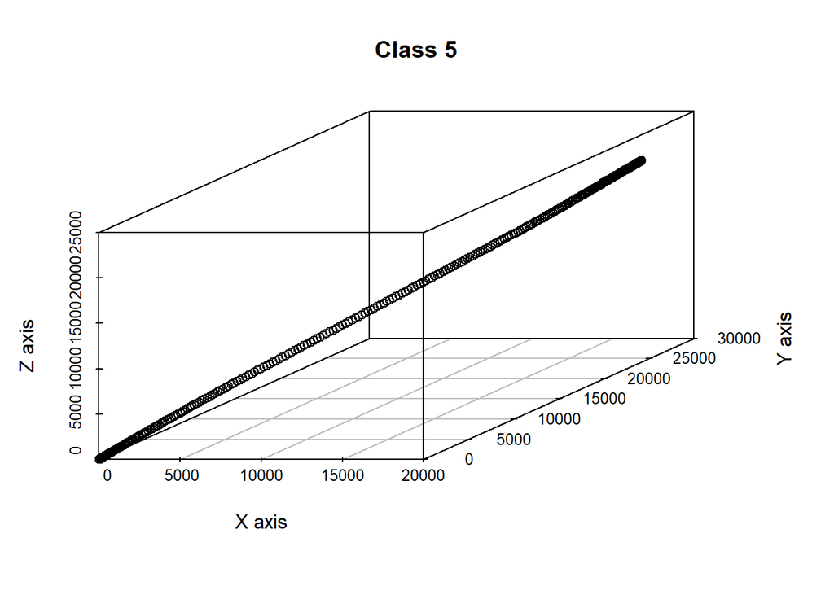

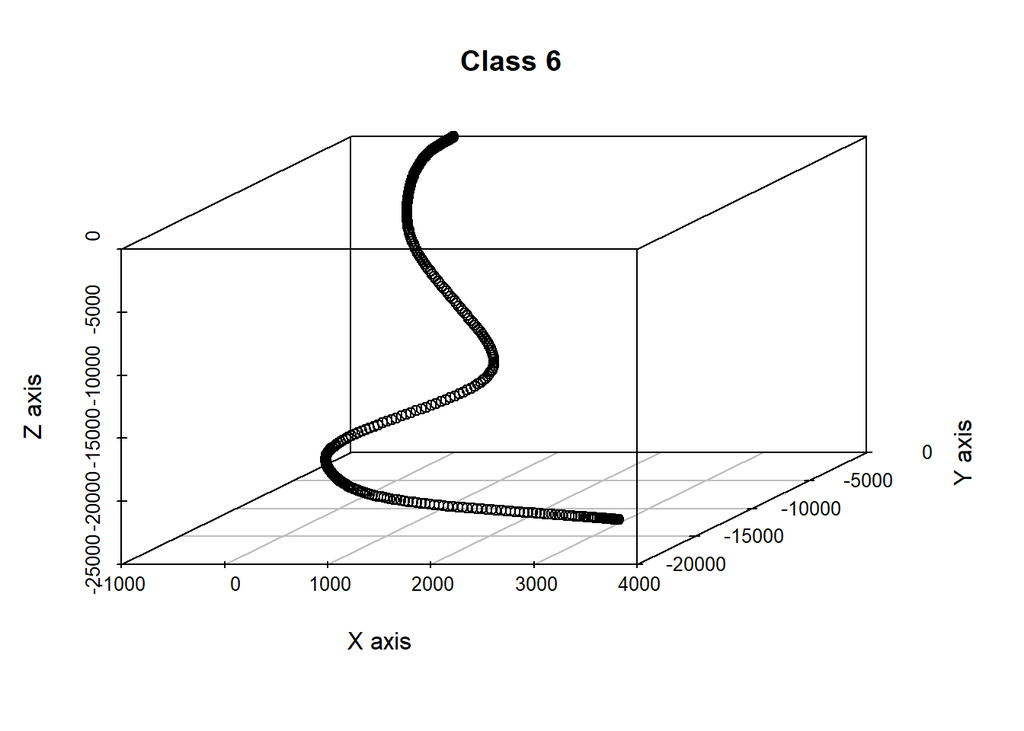

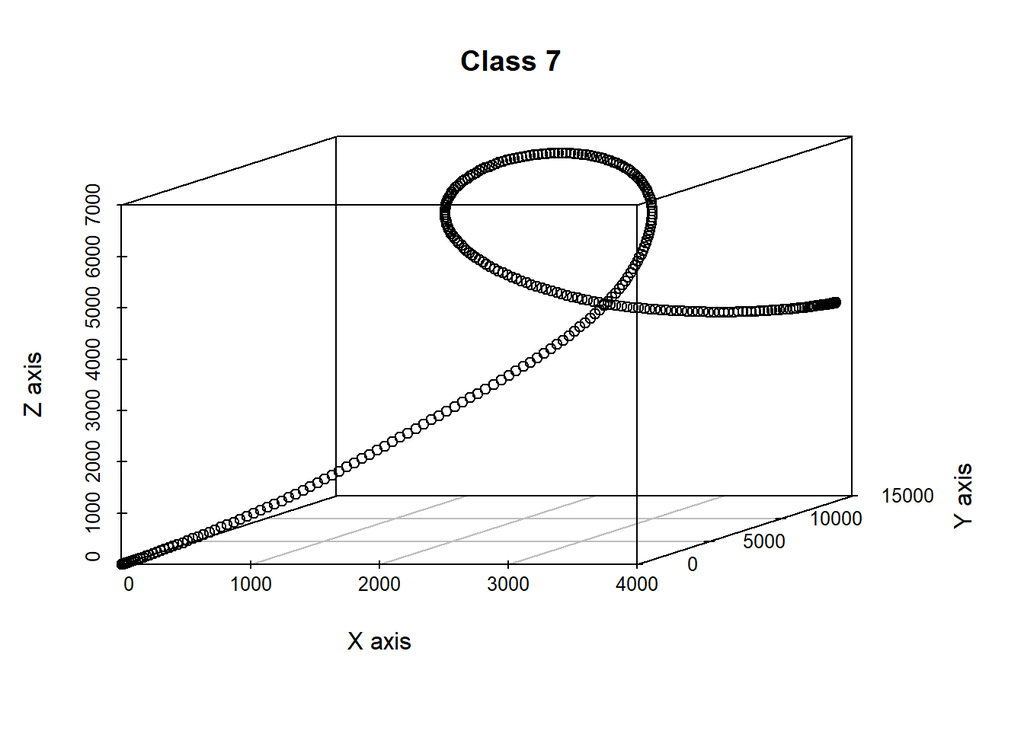

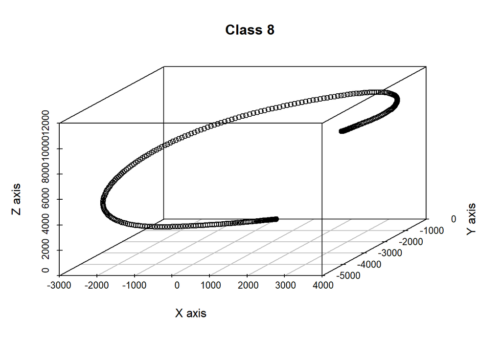

```r
library(scatterplot3d)
library(reshape)
library(ggplot2)
library(knitr)
opts_chunk$set(tidy.opts=list(width.cutoff=60),tidy=TRUE)
xtrain <- read.table("C:/Users/Toshiba/Desktop/UWave_TRAIN/uWaveGestureLibrary_X_TRAIN")
ytrain <- read.table("C:/Users/Toshiba/Desktop/UWave_TRAIN/uWaveGestureLibrary_Y_TRAIN")
ztrain <- read.table("C:/Users/Toshiba/Desktop/UWave_TRAIN/uWaveGestureLibrary_Z_TRAIN")
gesture_first <- c()
for (i in 1:8) {
  gesture_first <- append(gesture_first, match(i, xtrain$V1))
}
xtrain_v1_temp <- xtrain$V1
xtrain$V1 <- 0
xtrain_velocity <- apply(xtrain, 1, cumsum)
xtrain_velocity <- t(xtrain_velocity)
xtrain_location <- apply(xtrain_velocity, 1, cumsum)
xtrain_location <- t(xtrain_location)
xtrain_location <- as.data.frame(xtrain_location)
xtrain_location <- mutate(xtrain_location, V1 = xtrain_v1_temp)
ytrain_v1_temp <- ytrain$V1
ytrain$V1 <- 0
ytrain_velocity <- apply(ytrain, 1, cumsum)
ytrain_velocity <- t(ytrain_velocity)
ytrain_location <- apply(ytrain_velocity, 1, cumsum)
ytrain_location <- t(ytrain_location)
ytrain_location <- as.data.frame(ytrain_location)
ytrain_location <- mutate(ytrain_location, V1 = ytrain_v1_temp)
ztrain_v1_temp <- ytrain_v1_temp
ztrain$V1 <- 0
ztrain_velocity <- apply(ztrain, 1, cumsum)
ztrain_velocity <- t(ztrain_velocity)
ztrain_location <- apply(ztrain_velocity, 1, cumsum)
ztrain_location <- t(ztrain_location)
ztrain_location <- as.data.frame(ztrain_location)
ztrain_location <- mutate(ztrain_location, V1 = ztrain_v1_temp)
xtrain_location_matrix <- as.matrix(xtrain_location)
ytrain_location_matrix <- as.matrix(ytrain_location)
ztrain_location_matrix <- as.matrix(ztrain_location)
for (i in 1:8) {
  scatterplot3d(xtrain_location_matrix[gesture_first[i], -1], ytrain_location_matrix[gesture_first[i], -1], ztrain_location_matrix[gesture_first[i], -1], main = paste("Class", i), xlab = "X axis", ylab = "Y axis", zlab = "Z axis")
}
```

Observations from different classes show unique patterns on 3D plots. It is quite easy to distinguish one class from another examining their plots.

```r
xtrain_long <- mutate(xtrain_location, id = 1:896)
xtrain_long <- melt(xtrain_long, id.vars = c("id", "V1"))
xtrain_long <- transmute(xtrain_long, time_series_id = id, time_index = variable, x = value, class = V1)
ytrain_long <- mutate(ytrain_location, id = 1:896)
ytrain_long <- melt(ytrain_long, id.vars = c("id", "V1"))
ytrain_long <- transmute(ytrain_long, time_series_id = id, time_index = variable, y = value, class = V1)
ztrain_long <- mutate(ztrain_location, id = 1:896)
ztrain_long <- melt(ztrain_long, id.vars = c("id", "V1"))
ztrain_long <- transmute(ztrain_long, time_series_id = id, time_index = variable, z = value, class = V1)
wholetrain <- select(xtrain_long, time_series_id, time_index, x)
wholetrain <- mutate(wholetrain, y = ytrain_long$y, z = ztrain_long$z, class = ztrain_long$class)
wholetrain$time_index <- sub(".", "", wholetrain$time_index)
wholetrain$time_index <- as.numeric(wholetrain$time_index)
wholetrain$time_index <- wholetrain$time_index - 1
wholetrain_pca <- princomp(wholetrain[, 3:5], cor = TRUE)
summary(wholetrain_pca, loadings = TRUE)
```

```
## Importance of components:
##                           Comp.1    Comp.2    Comp.3
## Standard deviation     1.2724995 1.0380930 0.5505524
## Proportion of Variance 0.5397517 0.3592124 0.1010360
## Cumulative Proportion  0.5397517 0.8989640 1.0000000
##
## Loadings:
##   Comp.1 Comp.2 Comp.3
## x  0.209  0.908  0.362
## y  0.723  0.105 -0.683
## z  0.658 -0.404  0.635
```

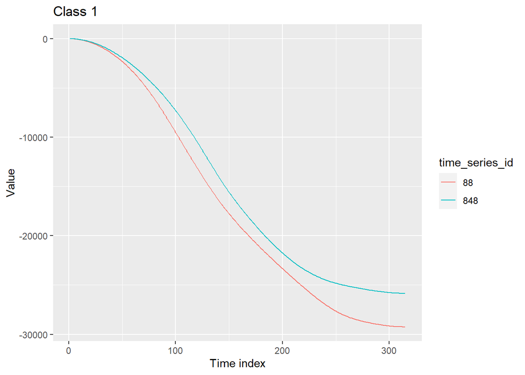

```r
univariate <- mutate(wholetrain, pca_value = x*0.209 + y*0.723 + z*0.658)
univariate <- select(univariate, -x, -y, -z)
class_one <- filter(univariate, univariate$time_series_id == 88 | univariate$time_series_id == 848)
class_one <- mutate(class_one, time_series_id = as.factor(time_series_id))
class_two <- filter(univariate, univariate$time_series_id == 58 | univariate$time_series_id == 841)
class_two <- mutate(class_two, time_series_id = as.factor(time_series_id))
class_three <- filter(univariate, univariate$time_series_id == 290 | univariate$time_series_id ==331)
class_three <- mutate(class_three, time_series_id = as.factor(time_series_id))
class_four <- filter(univariate, univariate$time_series_id == 222 | univariate$time_series_id ==642)
class_four <- mutate(class_four, time_series_id = as.factor(time_series_id))
class_five <- filter(univariate, univariate$time_series_id == 2 | univariate$time_series_id ==896)
class_five <- mutate(class_five, time_series_id = as.factor(time_series_id))
class_six <- filter(univariate, univariate$time_series_id == 512 | univariate$time_series_id ==881)
class_six <- mutate(class_six, time_series_id = as.factor(time_series_id))
class_seven <- filter(univariate, univariate$time_series_id == 670 | univariate$time_series_id ==792)
class_seven <- mutate(class_seven, time_series_id = as.factor(time_series_id))
class_eight <- filter(univariate, univariate$time_series_id == 168 | univariate$time_series_id ==255)
class_eight <- mutate(class_eight, time_series_id = as.factor(time_series_id))
ggplot(class_one, aes(x = time_index, y = pca_value, colour = time_series_id)) + geom_line() + xlab("Time index") + ylab("Value") + ggtitle("Class 1")
```

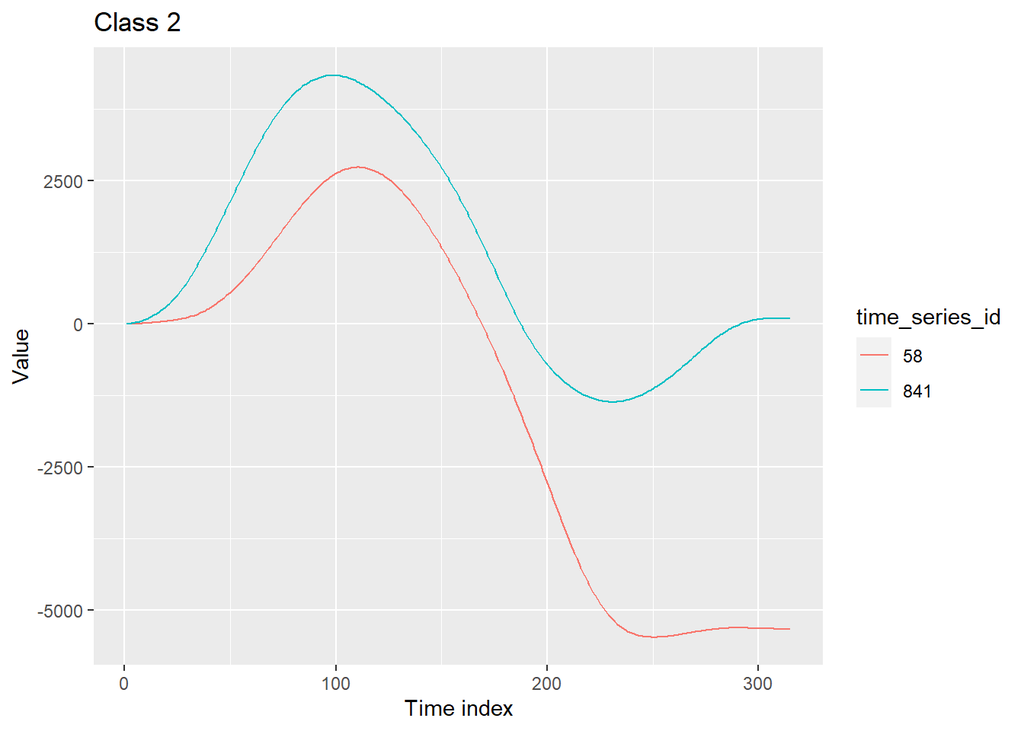

```r
ggplot(class_two, aes(x = time_index, y = pca_value, colour = time_series_id)) + geom_line() + xlab("Time index") + ylab("Value") + ggtitle("Class 2")
```

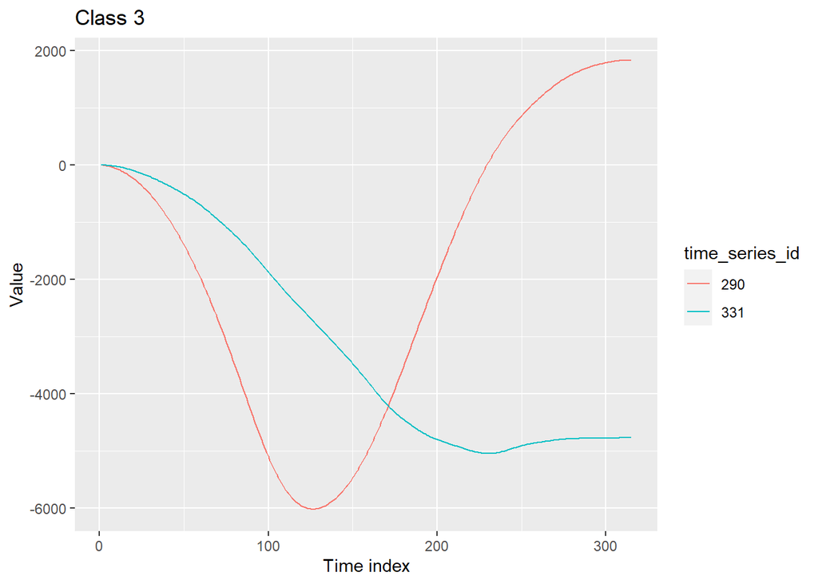

```r
ggplot(class_three, aes(x = time_index, y = pca_value, colour = time_series_id)) + geom_line() + xlab("Time index") + ylab("Value") + ggtitle("Class 3")
```

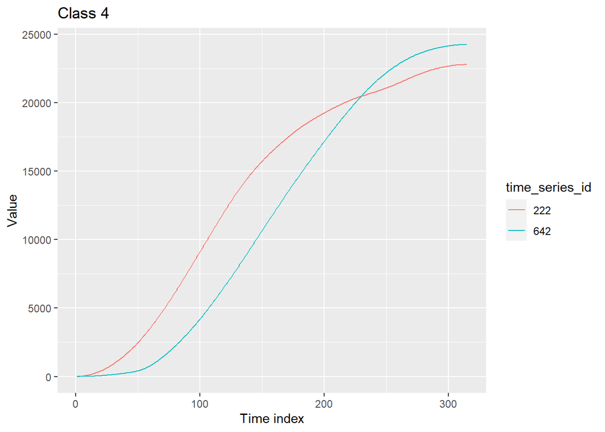

```r
ggplot(class_four, aes(x = time_index, y = pca_value, colour = time_series_id)) + geom_line() + xlab("Time index") + ylab("Value") + ggtitle("Class 4")
```

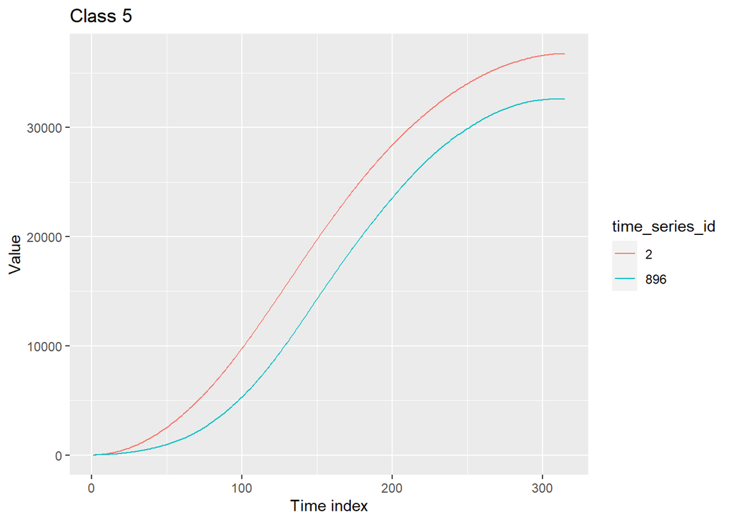

```r
ggplot(class_five, aes(x = time_index, y = pca_value, colour = time_series_id)) + geom_line() + xlab("Time index") + ylab("Value") + ggtitle("Class 5")
```

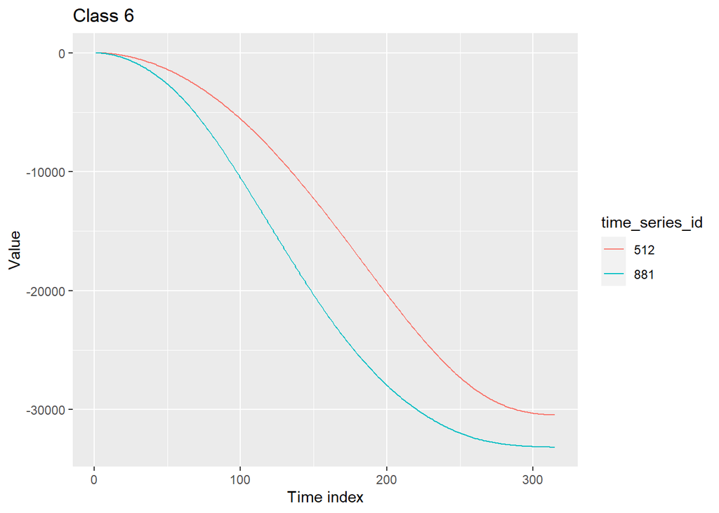

```r
ggplot(class_six, aes(x = time_index, y = pca_value, colour = time_series_id)) + geom_line() + xlab("Time index") + ylab("Value") + ggtitle("Class 6")
```

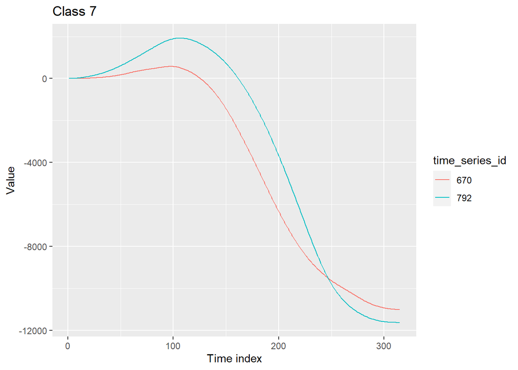

```r
ggplot(class_seven, aes(x = time_index, y = pca_value, colour = time_series_id)) + geom_line() + xlab("Time index") + ylab("Value") + ggtitle("Class 7")
```

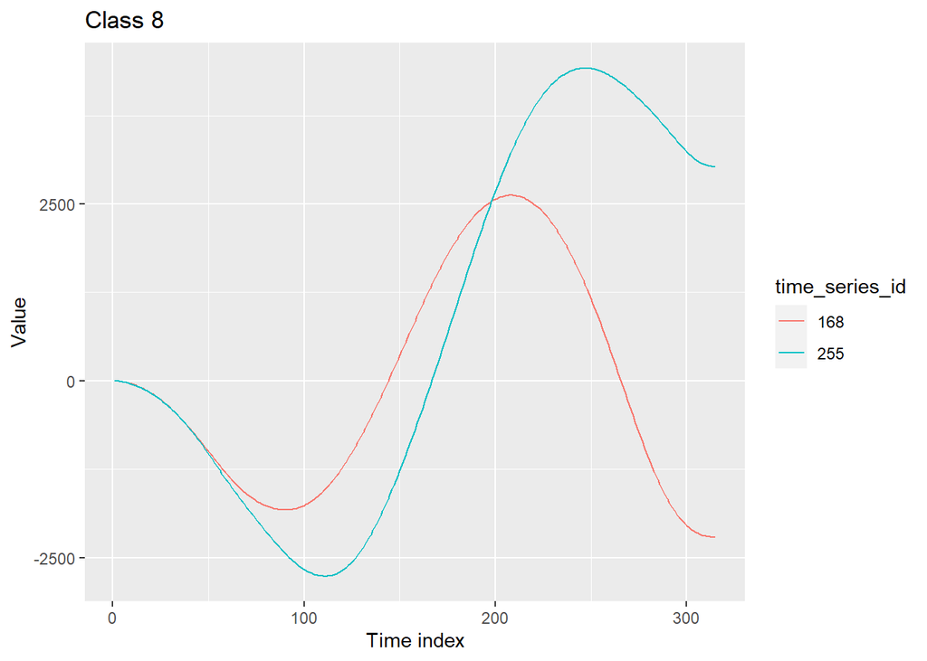

```r
ggplot(class_eight, aes(x = time_index, y = pca_value, colour = time_series_id)) + geom_line() + xlab("Time index") + ylab("Value") + ggtitle("Class 8")
```

Observations from different classes show *relatively* unique patterns on when plotted on 2D, but the patterns are not as distinguishing as they were in 3D plots. There is an observable reduction in separability of classes due to reduction in dimensions. 2D plots would still help but they are definitely not as reliable as 3D plots since observations from different classes might show similar patterns on 2D.

```r
wholetrain_one <- filter(wholetrain, wholetrain$class == 1)
wholetrain_one_pca <- princomp(wholetrain_one[, 3:5], cor = TRUE)
summary(wholetrain_one_pca, loadings = TRUE)
```

```
## Importance of components:
##                           Comp.1    Comp.2    Comp.3
## Standard deviation     1.2932492 1.0091473 0.5559931
## Proportion of Variance 0.5574978 0.3394594 0.1030428
## Cumulative Proportion  0.5574978 0.8969572 1.0000000
##
## Loadings:
##   Comp.1 Comp.2 Comp.3
## x  0.119  0.973  0.198
## y  0.693 -0.224  0.685
## z  0.711        -0.701
```

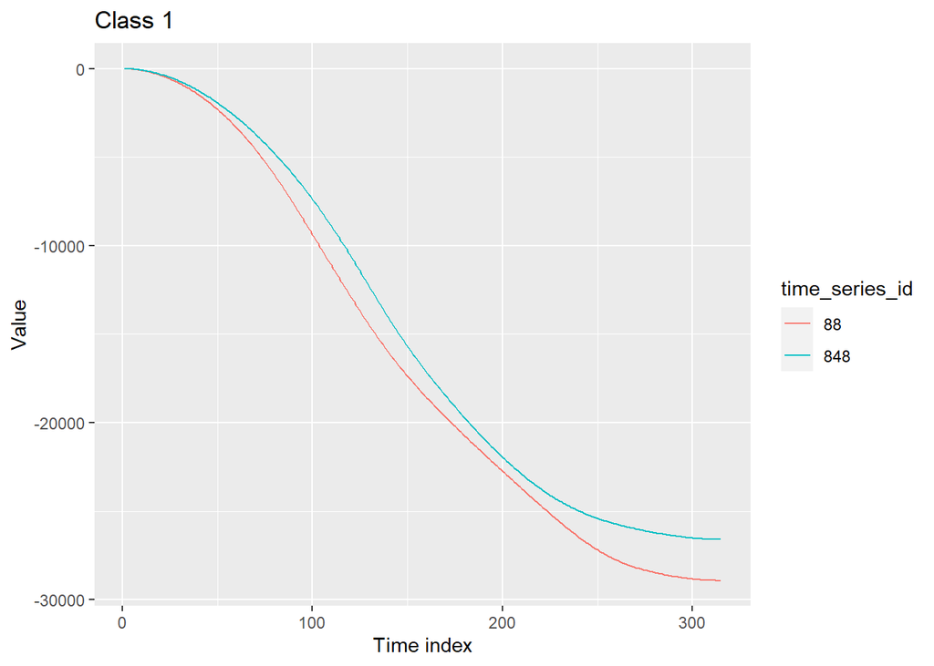

```r
univariate_one <- mutate(wholetrain_one, pca_value = x*0.119 + y*0.693 + z*0.711)
univariate_one <- select(univariate_one, -x, -y, -z)
class_one_only <- filter(univariate_one, univariate_one$time_series_id == 88 | univariate_one$time_series_id == 848)
class_one_only <- mutate(class_one_only, time_series_id = as.factor(time_series_id))
ggplot(class_one_only, aes(x = time_index, y = pca_value, colour = time_series_id)) + geom_line() + xlab("Time index") + ylab("Value") + ggtitle("Class 1")
```

```r
wholetrain_two <- filter(wholetrain, wholetrain$class == 2)
wholetrain_two_pca <- princomp(wholetrain_two[, 3:5], cor = TRUE)
summary(wholetrain_two_pca, loadings = TRUE)
```

```
## Importance of components:
##                           Comp.1    Comp.2    Comp.3
## Standard deviation     1.1286537 0.9457021 0.9120243
## Proportion of Variance 0.4246197 0.2981175 0.2772628
## Cumulative Proportion  0.4246197 0.7227372 1.0000000
##
## Loadings:
##   Comp.1 Comp.2 Comp.3
## x  0.535  0.814  0.224
## y  0.613 -0.192 -0.767
## z  0.581 -0.548  0.602
```

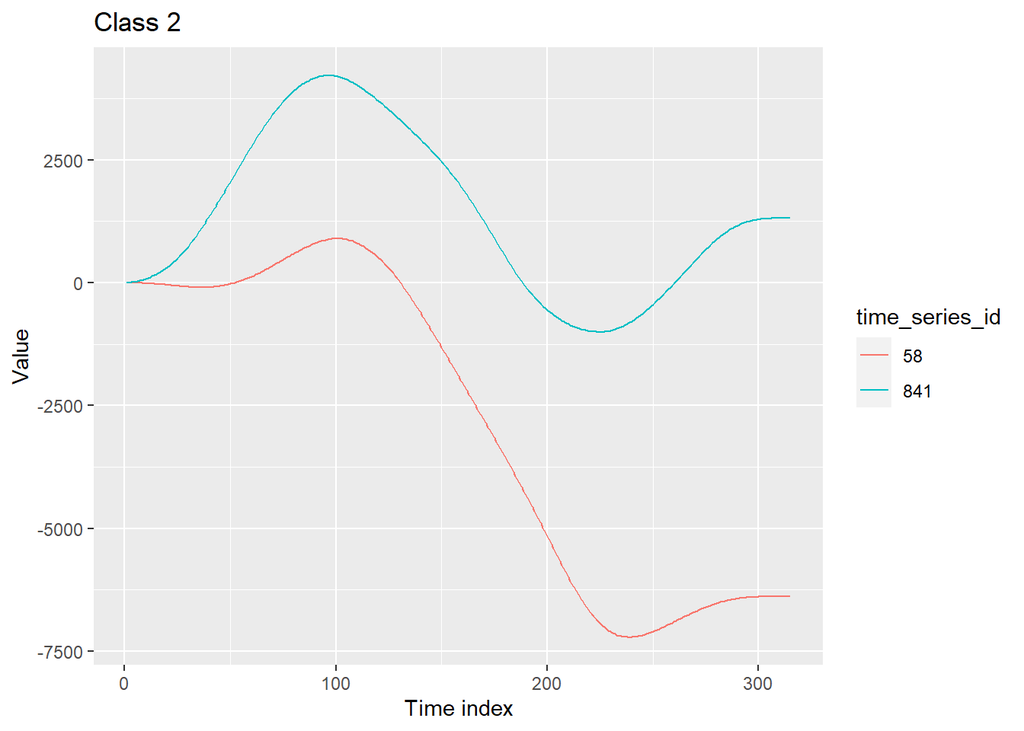

```r
univariate_two <- mutate(wholetrain_two, pca_value = x*0.535 + y*0.613 + z*0.581)
univariate_two <- select(univariate_two, -x, -y, -z)
class_two_only <- filter(univariate_two, univariate_two$time_series_id == 58 | univariate_two$time_series_id == 841)
class_two_only <- mutate(class_two_only, time_series_id = as.factor(time_series_id))
ggplot(class_two_only, aes(x = time_index, y = pca_value, colour = time_series_id)) + geom_line() + xlab("Time index") + ylab("Value") + ggtitle("Class 2")
```

```r
wholetrain_three <- filter(wholetrain, wholetrain$class == 3)
wholetrain_three_pca <- princomp(wholetrain_three[, 3:5], cor = TRUE)
summary(wholetrain_three_pca, loadings = TRUE)
```

```
## Importance of components:
##                           Comp.1    Comp.2    Comp.3
## Standard deviation     1.2156489 1.0027730 0.7187794
## Proportion of Variance 0.4926008 0.3351846 0.1722146
## Cumulative Proportion  0.4926008 0.8277854 1.0000000
##
## Loadings:
##   Comp.1 Comp.2 Comp.3
## x  0.709         0.705
## y  0.371  0.847 -0.380
## z -0.599  0.532  0.599
```

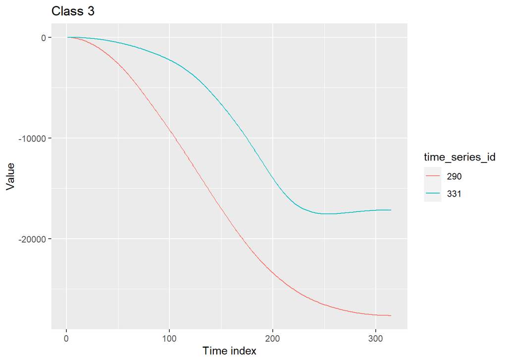

```r
univariate_three <- mutate(wholetrain_three, pca_value = x*0.709 + y*0.371 - z*0.599)
univariate_three <- select(univariate_three, -x, -y, -z)
class_three_only <- filter(univariate_three, univariate_three$time_series_id == 290 | univariate_three$time_series_id == 331)
class_three_only <- mutate(class_three_only, time_series_id = as.factor(time_series_id))
ggplot(class_three_only, aes(x = time_index, y = pca_value, colour = time_series_id)) + geom_line() + xlab("Time index") + ylab("Value") + ggtitle("Class 3")
```

```r
wholetrain_four <- filter(wholetrain, wholetrain$class == 4)
wholetrain_four_pca <- princomp(wholetrain_four[, 3:5], cor = TRUE)
summary(wholetrain_four_pca, loadings = TRUE)
```

```
## Importance of components:
##                           Comp.1    Comp.2    Comp.3
## Standard deviation     1.2855781 0.9914895 0.6035210
## Proportion of Variance 0.5509037 0.3276838 0.1214125
## Cumulative Proportion  0.5509037 0.8785875 1.0000000
##
## Loadings:
##   Comp.1 Comp.2 Comp.3
## x  0.702         0.711
## y  0.674  0.285 -0.681
## z -0.230  0.958  0.173
```

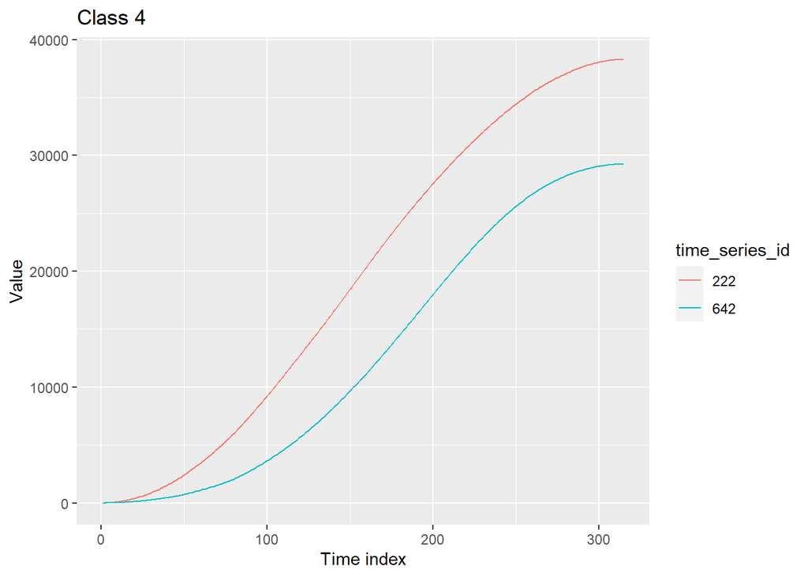

```r
univariate_four <- mutate(wholetrain_four, pca_value = x*0.702 + y*0.674 - z*0.230)
univariate_four <- select(univariate_four, -x, -y, -z)
class_four_only <- filter(univariate_four, univariate_four$time_series_id == 222 | univariate_four$time_series_id == 642)
class_four_only <- mutate(class_four_only, time_series_id = as.factor(time_series_id))
ggplot(class_four_only, aes(x = time_index, y = pca_value, colour = time_series_id)) + geom_line() + xlab("Time index") + ylab("Value") + ggtitle("Class 4")
```

```r
wholetrain_five <- filter(wholetrain, wholetrain$class == 5)
wholetrain_five_pca <- princomp(wholetrain_five[, 3:5], cor = TRUE)
summary(wholetrain_five_pca, loadings = TRUE)
```

```
## Importance of components:
##                           Comp.1    Comp.2     Comp.3
## Standard deviation     1.4038307 0.9685920 0.30180949
## Proportion of Variance 0.6569135 0.3127235 0.03036299
## Cumulative Proportion  0.6569135 0.9696370 1.00000000
##
## Loadings:
##   Comp.1 Comp.2 Comp.3
## x  0.245  0.970
## y  0.685 -0.177  0.707
## z  0.686 -0.170 -0.708
```

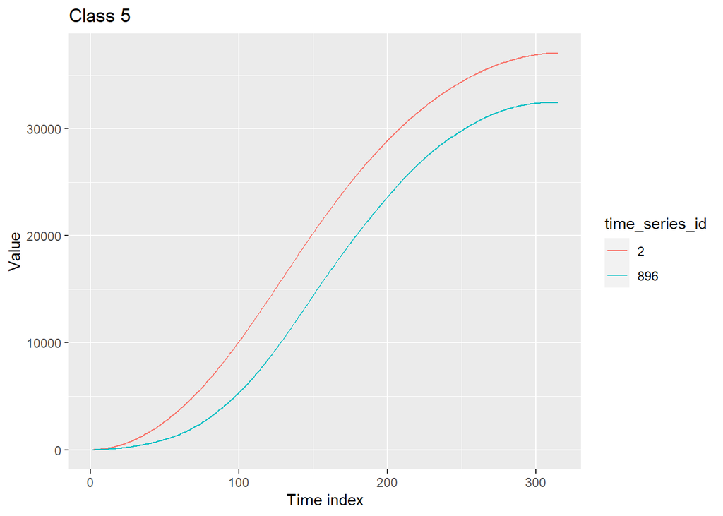

```r
univariate_five <- mutate(wholetrain_five, pca_value = x*0.245 + y*0.685 + z*0.686)
univariate_five <- select(univariate_five, -x, -y, -z)
class_five_only <- filter(univariate_five, univariate_five$time_series_id == 2 | univariate_five$time_series_id == 896)
class_five_only <- mutate(class_five_only, time_series_id = as.factor(time_series_id))
ggplot(class_five_only, aes(x = time_index, y = pca_value, colour = time_series_id)) + geom_line() + xlab("Time index") + ylab("Value") + ggtitle("Class 5")
```

```r
wholetrain_six <- filter(wholetrain, wholetrain$class == 6)
wholetrain_six_pca <- princomp(wholetrain_six[, 3:5], cor = TRUE)
summary(wholetrain_six_pca, loadings = TRUE)
```

```
## Importance of components:
##                           Comp.1    Comp.2     Comp.3
## Standard deviation     1.3400570 0.9638120 0.52470332
## Proportion of Variance 0.5985843 0.3096445 0.09177119
## Cumulative Proportion  0.5985843 0.9082288 1.00000000
##
## Loadings:
##   Comp.1 Comp.2 Comp.3
## x  0.291  0.955
## y -0.671  0.251 -0.698
## z -0.682  0.162  0.713
```

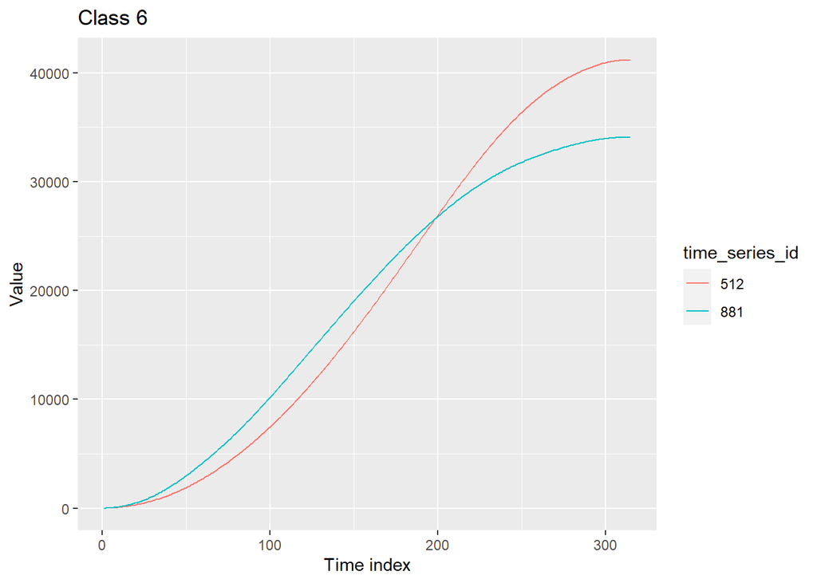

```r
univariate_six <- mutate(wholetrain_six, pca_value = x*0.291 - y*0.671 - z*0.682)
univariate_six <- select(univariate_six, -x, -y, -z)
class_six_only <- filter(univariate_six, univariate_six$time_series_id == 512 | univariate_six$time_series_id == 881)
class_six_only <- mutate(class_six_only, time_series_id = as.factor(time_series_id))
ggplot(class_six_only, aes(x = time_index, y = pca_value, colour = time_series_id)) + geom_line() + xlab("Time index") + ylab("Value") + ggtitle("Class 6")
```

```r
wholetrain_seven <- filter(wholetrain, wholetrain$class == 7)
wholetrain_seven_pca <- princomp(wholetrain_seven[, 3:5], cor = TRUE)
summary(wholetrain_seven_pca, loadings = TRUE)
```

```
## Importance of components:
##                           Comp.1    Comp.2    Comp.3
## Standard deviation     1.2971922 0.8883869 0.7266781
## Proportion of Variance 0.5609026 0.2630771 0.1760203
## Cumulative Proportion  0.5609026 0.8239797 1.0000000
##
## Loadings:
##   Comp.1 Comp.2 Comp.3
## x  0.596  0.487  0.639
## y  0.632  0.207 -0.747
## z  0.496 -0.849  0.184
```

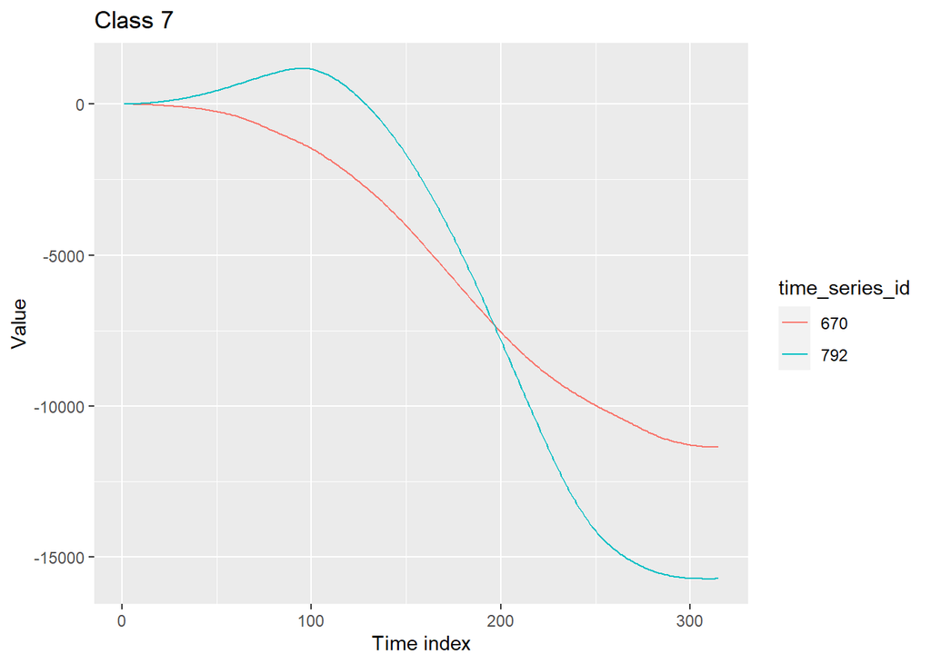

```r
univariate_seven <- mutate(wholetrain_seven, pca_value = x*0.596 + y*0.632 + z*0.496)
univariate_seven <- select(univariate_seven, -x, -y, -z)
class_seven_only <- filter(univariate_seven, univariate_seven$time_series_id == 670 | univariate_seven$time_series_id == 792)
class_seven_only <- mutate(class_seven_only, time_series_id = as.factor(time_series_id))
ggplot(class_seven_only, aes(x = time_index, y = pca_value, colour = time_series_id)) + geom_line() + xlab("Time index") + ylab("Value") + ggtitle("Class 7")
```

```r
wholetrain_eight <- filter(wholetrain, wholetrain$class == 8)
wholetrain_eight_pca <- princomp(wholetrain_eight[, 3:5], cor = TRUE)
summary(wholetrain_eight_pca, loadings = TRUE)
```

```
## Importance of components:
##                           Comp.1    Comp.2    Comp.3
## Standard deviation     1.2203138 0.9683089 0.7571078
## Proportion of Variance 0.4963886 0.3125407 0.1910707
## Cumulative Proportion  0.4963886 0.8089293 1.0000000
##
## Loadings:
##   Comp.1 Comp.2 Comp.3
## x  0.664  0.253  0.704
## y  0.337 -0.941
## z  0.668  0.223 -0.710
```

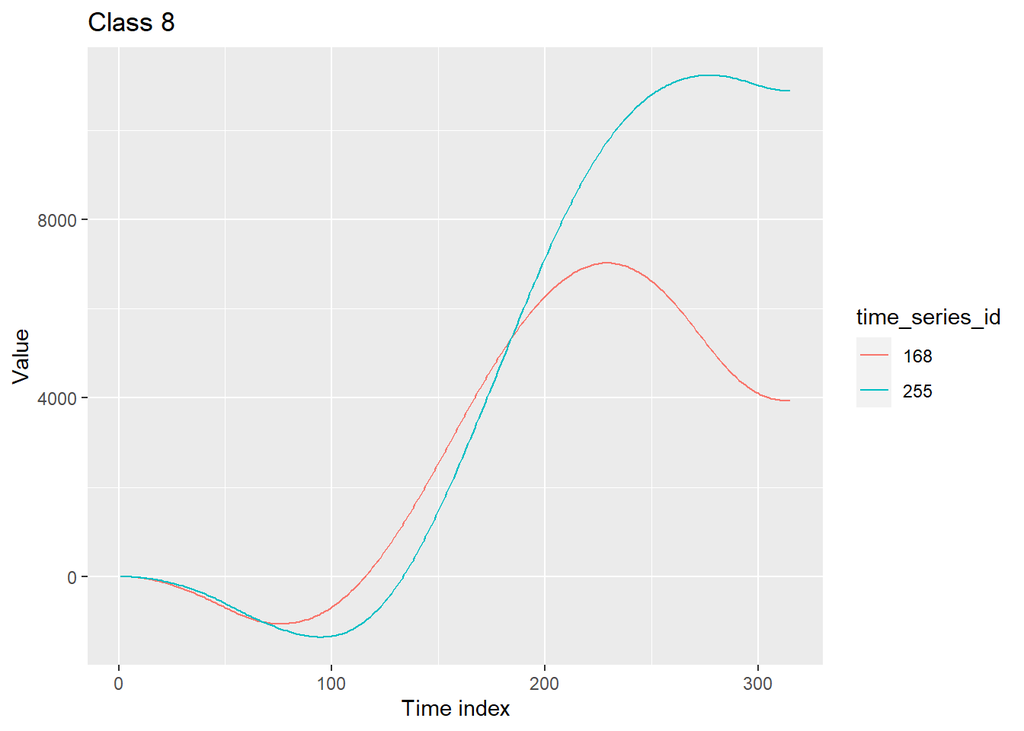

```r
univariate_eight <- mutate(wholetrain_eight, pca_value = x*0.664 + y*0.337 + z*0.668)
univariate_eight <- select(univariate_eight, -x, -y, -z)
class_eight_only <- filter(univariate_eight, univariate_eight$time_series_id == 168 | univariate_eight$time_series_id == 255)
class_eight_only <- mutate(class_eight_only, time_series_id = as.factor(time_series_id))
ggplot(class_eight_only, aes(x = time_index, y = pca_value, colour = time_series_id)) + geom_line() + xlab("Time index") + ylab("Value") + ggtitle("Class 8")
```

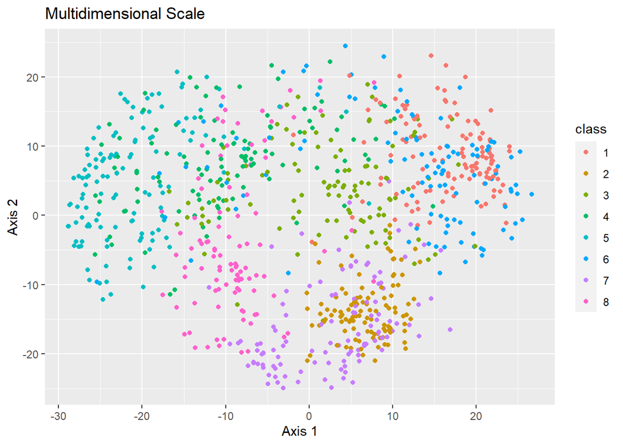

```r
xtrain <- mutate(xtrain, V1 = xtrain_v1_temp)
ytrain_edit <- ytrain[, -1]
ztrain_edit <- ztrain[, -1]
whole_data <- cbind(xtrain, ytrain_edit, ztrain_edit)
whole_data_edit <- whole_data[, -1]
whole_data_edit <- scale(whole_data_edit)
distance <- dist(whole_data_edit, method = "euclidean")
dist_matrix <- as.matrix(distance)
dist_md <- cmdscale(dist_matrix, k = 2)
data_md <- select(whole_data, V1)
data_md <- mutate(data_md, axis_one = dist_md[, 1], axis_two = dist_md[, 2], class = as.factor(V1))
ggplot(data_md) + geom_point(aes(x = axis_one, y = axis_two, colour = class)) + xlab("Axis 1") + ylab("Axis 2") + ggtitle("Multidimensional Scale")
```

Points from the class seem to be grouped, but the picture is not very clear. The plot might help showing that there is a noticeable difference between the distribution of points from different classes, but one definitely cannot distinguish one class from another depending solely on this plot.